# In Class Practice

## Costume Party

Suppose you’re attending a Marvel costume party. There are 10 people invited, and the host has specified that everyone should choose from one of the following 10 costumes:

- Spiderman
- Black Panther
- Scarlet Witch
- Iron Man
- Black Widow
- The Wasp
- Thanos
- Gamora
- Groot
- Captain Marvel

Unfortunately, you arrive early (well, on time, but you know, BYU standard time). As guests arrive, you grow nervous that someone will be wearing your same costume. As the number of guests grows, what’s the probability that someone is wearing your same costume? Be sure to assess the monte carlo error of your estimate.

```r
# Write a function with the following parameters:
#   n: the number of people at the party (not counting yourself)
#   n_reps: the number of times to run the simulation
# This function should return a numeric vector of length 3 containing an estimate
# of the probability that someone is wearing your same costume for the given value
# of n along with the upper and lower bounds of your confidence interval.

costume_party <- function(n, n_reps = 1000) {
  my_costume <- sample(1:10, 1)
  prop <- mean(replicate(n_reps, any(sample(1:10, n, replace = TRUE) == my_costume)))
  ci <- prop * qnorm(0.975) * (prop * (1 - prop)) / n_reps
  data.frame(
    lower = prop - ci,
    prop = prop,
    upper = prop + ci
  )
}
```

```r
costume_output <- purrr::map_df(1:30, costume_party, 50)
costume_output
```

| lower | prop | upper |
| --- | --- | --- |
| 0.13933926 | 0.14 | 0.1406607 |
| 0.09964721 | 0.10 | 0.1003528 |
| 0.19874562 | 0.20 | 0.2012544 |
| 0.37649057 | 0.38 | 0.3835094 |
| 0.51491225 | 0.52 | 0.5250878 |
| 0.41598944 | 0.42 | 0.4240106 |
| 0.39623687 | 0.40 | 0.4037631 |
| 0.61427408 | 0.62 | 0.6257259 |
| 0.51491225 | 0.52 | 0.5250878 |
| 0.63421983 | 0.64 | 0.6457802 |

[output cut: 20 more lines]

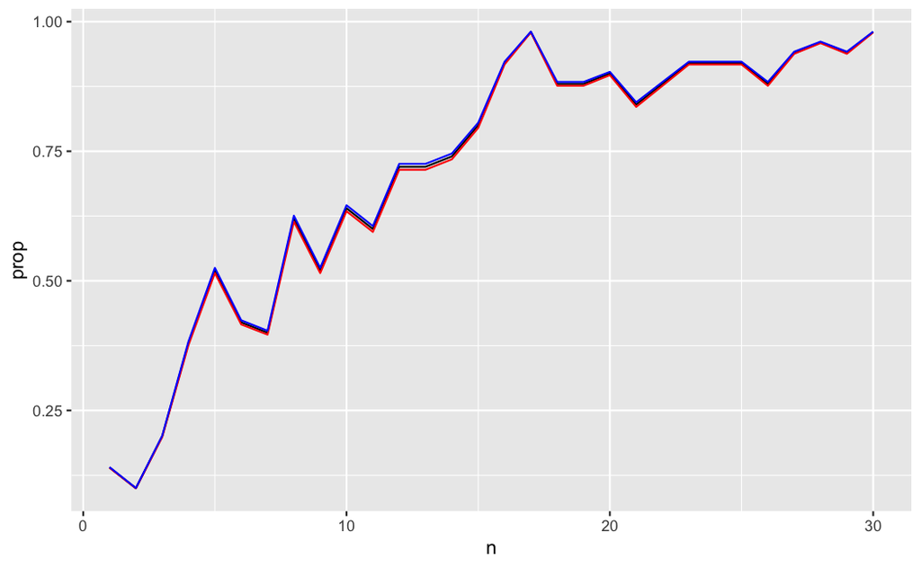

```r
library(tidyverse)
costume_output %>%
  mutate(n = 1:n()) %>%
  ggplot(aes(x = n, y = prop)) +
  geom_line() +
  geom_line(aes(y = lower), col = "red") +
  geom_line(aes(y = upper), col = "blue")
```

## Rolling in the deep

Suppose you’re playing a game using a six sided dice. The object of the game is to roll each number at least once. What’s the expected number of rolls it takes until each number has been rolled once? Be sure to assess the monte carlo error of your estimate.

Now, what happens in this scenario with a 10 sided dice? What about a 20 sided dice?

```r
# Write a function with the following parameters:
#   n: number of sides on the dice
# This function should return the number of rolls it took to roll all n sides at
# least once.
roll_dice <- function(n = 6) {
  dice_counts <- numeric(n)

  while(any(dice_counts == 0)) {
    roll <- sample(1:n, 1)
    dice_counts[roll] <- dice_counts[roll] + 1
  }

  sum(dice_counts)
}

# Using the function previously defined, simulate this action thousands of times
# to determine the expected number of rolls needed to roll each side at least once.
# Assess the monte carlo error of the estimate.

n_reps <- 10000
roll_counts <- replicate(n_reps, roll_dice())

expected_rolls <- mean(roll_counts)
expected_rolls
```

[output not shown]

## True value for birthday problem

```r
n <- 2:75
true_value <- 1 - (factorial(n) * choose(365, n)) / 365 ^ n
```